# Advanced Modelling - Final Assignment

Author

Gür Piren

Published

March 20, 2025

## 1 INTRODUCTION

This study investigates the factors influencing obesity by analyzing a dataset containing demographic, lifestyle, and behavioral variables such as age, gender, family history of overweight, eating habits, and physical activity. The primary goal is to classify individuals into four obesity levels—Insufficient Weight, Normal Weight, Overweight, and Obesity—using classification techniques like Random Forest, QDA, and Multinomial Logistic Regression, focusing on both prediction accuracy and interpretability of key predictors. Additionally, the study aims to predict an individual’s weight as a numerical outcome through advanced regression methods, including Ridge, Lasso, Elastic Net, and Random Forest regression, to understand the impact of these factors on weight and improve predictive performance for obesity-related outcomes.

## 2 PACKAGES

```r
rm(list=ls())

library(tidyverse)
library(dplyr)
library(stringr)
library(explore)
library(DataExplorer)
library(gtsummary)
library(skimr)
library(codebook)
library(knitr)
library(kableExtra)
library(MASS)
library(caret)
library(nnet)
library(ggeffects)
library(ggiraphExtra)
library(smotefamily)
library(randomForest)
library(MLmetrics)
library(pdp)
library(glmnet)
library(gridExtra)
library(xgboost)
```

## 3 DATA AND DESCRIPTIVE ANALYSIS

Reading the data

```r
data <- read.csv("ObesityDataSet.csv")

is.data.frame(data)
```

```
[1] TRUE
```

### 3.1 Data Cleaning

We already have our dataset as a data frame

Some of the variables do not have informative names and I prefer fixing that. In doing so, I’ll be using the ‘Variables Table’ from the source website:

https://archive.ics.uci.edu/dataset/544/estimation+of+obesity+levels+based+on+eating+habits+and+physical+condition

```r
colnames(data)
```

```
 [1] "Gender"                         "Age"
 [3] "Height"                         "Weight"
 [5] "family_history_with_overweight" "FAVC"
 [7] "FCVC"                           "NCP"
 [9] "CAEC"                           "SMOKE"
[11] "CH2O"                           "SCC"
[13] "FAF"                            "TUE"
[15] "CALC"                           "MTRANS"
[17] "NObeyesdad"
```

```r
data <- data |>
  rename(
    eats_high_cal_freq = FAVC,
    meals_w_vegetables = FCVC,
    daily_meals = NCP,
    eats_btw_meals = CAEC,
    daily_water = CH2O,
    monitors_calories = SCC,
    physical_activity_freq = FAF,
    time_on_devices = TUE,
    alcohol_freq = CALC,
    transportation_type = MTRANS,
    obesity_level = NObeyesdad
  )


# I also want to fix the values some of the categorical variables take on, eliminating tokens such as underscores ('_') etc. See subsequent chunks for that.
```

Super weird, but some of the age values are written with decimals: 18.50334, 21.85383 etc.

I will round those numbers to the most approximate values.

I will perform the same procedure for Height and Weight values too, while converting Height into cm measure.

Quite interestingly, the variable for daily meals and daily meals with vegetables also takes on decimal numbers, I will approximate those values as well.

The situation is the same for the liters of water drunk for respondents. However I might actually consider leaving this as it is, because it can provide some variance and people do not drink precisely two or three liters of water.

Physical activities and time spent on technological devices are also reported as decimal numbers. I honestly don’t know why these are happening, however, I think the best solution is to approximate those values either to the floor or the ceiling depending on each number

Another problem relates to the column that indicates the frequencies of each respondent to eat in between his/her meals and alcohol usage.

eats_btw_meals: “Sometimes” “Frequently” “Always” “no”

alcohol_freq: “no” “Sometimes” “Frequently” “Always”

These are obviously unbalanced distributions of numbers, giving no representation for people who who ‘Rarely’ eats in between meals and uses alcohol. To address that, I considered inserting an additional level named ‘Rarely’, however, since the variables at hand are categorical and the responses are actually reported by the interviewees, it would be wrong to capture an answer that they did not explicitly selected.

That is why I will not change the structure of ‘eats_btw_meals’ and ‘alcohol_freq’, however, I think there is an inherent issue with the design of both variables.

```r
# not going to add a new level to 'eats_btw_meals' and 'alcohol_freq'
```

Finally, I will perform some adjustments in the values ‘obesity_level’ and ‘transportation_type’ variables take on, eliminating underscores (_) from values

```r
unique(data$obesity_level)
```

```
[1] "Normal_Weight"       "Overweight_Level_I"  "Overweight_Level_II"
[4] "Obesity_Type_I"      "Insufficient_Weight" "Obesity_Type_II"
[7] "Obesity_Type_III"
```

```r
data <- data |>
  mutate(
    obesity_level = str_replace_all(obesity_level, "_", " "),
    transportation_type = str_replace_all(transportation_type, "_", " "))
```

### 3.2 Variables

1. Gender - Categorical
2. Age - Continuous
3. Height - Continuous
4. Weight - Continuous
5. family_history_with_overweight - Binary

Has a family member suffered or suffers from overweight?

6. eats_high_cal_freq - Binary

Do you eat high caloric food frequently?

7. meals_w_vegetables - Integer

Do you usually eat vegetables in your meals?

8. daily_meals - Continuous

How many main meals do you have daily?

9. eats_btw_meals - Categorical

Do you eat any food between meals?

10. SMOKE - Binary

Do you smoke?

11. daily_water - Continuous

How much water do you drink daily?

12. monitors_calories - Binary

Do you monitor the calories you eat daily?

13. physical_activity_freq - Continuous

How often do you have physical activity?

14. time_on_devices - Integer

How much time do you use technological devices such as cell phone, videogames, television, computer and others?

15. alcohol_freq - Categorical

How often do you drink alcohol?

16. transportation_type - Categorical

Which transportation do you usually use?

17. obesity_level - Categorical

Obesity level

To see all the variable names and beyond, remove the chunk settings and check the codebook html file, the codebook will be shared in the submission file:

Let’s begin with exploring our dataset

The dataset consists of 2.111 observations across 17 variables, 9 of them being characters and 8 of them being numeric

There is no missing values in the dataset

```r
data |> describe_tbl()
```

```
2 111 (2.1k) observations with 17 variables
0 observations containing missings (NA)
0 variables containing missings (NA)
0 variables with no variance
```

```r
skim(data)
```

Data summary

| Name | data |
| --- | --- |
| Number of rows | 2111 |
| Number of columns | 17 |
| _______________________ |  |
| Column type frequency: |  |
| character | 9 |
| numeric | 8 |
| ________________________ |  |
| Group variables | None |

**Variable type: character**

| skim_variable | n_missing | complete_rate | min | max | empty | n_unique | whitespace |
| --- | --- | --- | --- | --- | --- | --- | --- |
| Gender | 0 | 1 | 4 | 6 | 0 | 2 | 0 |
| family_history_with_overweight | 0 | 1 | 2 | 3 | 0 | 2 | 0 |
| eats_high_cal_freq | 0 | 1 | 2 | 3 | 0 | 2 | 0 |
| eats_btw_meals | 0 | 1 | 2 | 10 | 0 | 4 | 0 |
| SMOKE | 0 | 1 | 2 | 3 | 0 | 2 | 0 |
| monitors_calories | 0 | 1 | 2 | 3 | 0 | 2 | 0 |
| alcohol_freq | 0 | 1 | 2 | 10 | 0 | 4 | 0 |
| transportation_type | 0 | 1 | 4 | 21 | 0 | 5 | 0 |
| obesity_level | 0 | 1 | 13 | 19 | 0 | 7 | 0 |

**Variable type: numeric**

| skim_variable | n_missing | complete_rate | mean | sd | p0 | p25 | p50 | p75 | p100 | hist |
| --- | --- | --- | --- | --- | --- | --- | --- | --- | --- | --- |
| Age | 0 | 1 | 24.32 | 6.36 | 14 | 20.00 | 23 | 26.00 | 61 | ▇▅▂▁▁ |
| Height | 0 | 1 | 170.16 | 9.34 | 145 | 163.00 | 170 | 177.00 | 198 | ▂▆▇▅▁ |
| Weight | 0 | 1 | 86.59 | 26.19 | 39 | 65.45 | 83 | 107.45 | 173 | ▆▇▆▂▁ |
| meals_w_vegetables | 0 | 1 | 2.42 | 0.58 | 1 | 2.00 | 2 | 3.00 | 3 | ▁▁▇▁▇ |
| daily_meals | 0 | 1 | 2.69 | 0.81 | 1 | 3.00 | 3 | 3.00 | 4 | ▂▁▁▇▁ |
| daily_water | 0 | 1 | 2.01 | 0.69 | 1 | 2.00 | 2 | 2.00 | 3 | ▃▁▇▁▃ |
| physical_activity_freq | 0 | 1 | 1.01 | 0.90 | 0 | 0.00 | 1 | 2.00 | 3 | ▇▇▁▅▁ |
| time_on_devices | 0 | 1 | 0.66 | 0.67 | 0 | 0.00 | 1 | 1.00 | 2 | ▇▁▇▁▂ |

**Sample Size:** The total number of respondents in the study is 2,111.

**Gender Distribution:** The gender distribution is relatively balanced, with 51% Male (1,068 respondents) and 49% Female (1,043 respondents).

**Age:** The mean age of respondents is 24 years, with a standard deviation of 6 years, indicating a youthful population.

**Height:** The average height is 170 cm with a standard deviation of 9 cm, reflecting a generally consistent height range among respondents.

**Weight:** The average weight is 86.59 kg with a standard deviation of 26.19 kg, suggesting variability in body weight among participants.

**Family History of Overweight:** A significant majority (82%) of respondents have a family history of overweight, indicating a potential genetic or environmental risk factor.

**High-Caloric Food:** A large percentage (88%) report frequently eating high-caloric foods.

**Meals with Vegetables:** Most participants eat vegetables in 2 (1,013 or 48%) or 3 (996 or 47%) of their meals, with only a small fraction (102 or 4.8%) consuming them in 1 meal.

**Daily Meals:** 70% have 3 main meals daily, while the remaining spread across 1 to 4 meals, indicating a preference for a three-meal structure.

**Eating Between Meals:** Majority: A significant 84% of respondents eat between meals “Sometimes,” indicating less frequent snacking among participants (the other categories have very low frequencies).

**Smoking Habits:** A small portion of participants (2.1%) reported being smokers.

**Daily Water Intake:** Water intake is moderately distributed with 53% consuming 2 liters daily; 24% hold 3 liters, and 23% consume only 1 liter.

**Monitoring Calories:** Only 4.5% of respondents actively monitor their calorie intake, suggesting that calorie counting may not be widely practiced among the sample.

**Physical Activity Frequency:** A large number of participants (34%) reported no physical activity (0), while the rest reported varying degrees of activity, with the largest group (37%) indicating a low level of activity (1).

**Time on Devices:** Most participants (45%) spend 0 (probably 0 to 1) hours on devices, while 43% spend 1 (1 to less than 2) hour, indicating diverse usage patterns of technology.

**Alcohol Consumption:** A notable 66% of respondents reported “Sometimes” consuming alcohol, with 30% stating they do not drink at all.

**Transportation Choices:** 75% of respondents use public transportation, indicating a significant reliance on public transit. Cars, bikes, and walking are used minimally compared to public transport.

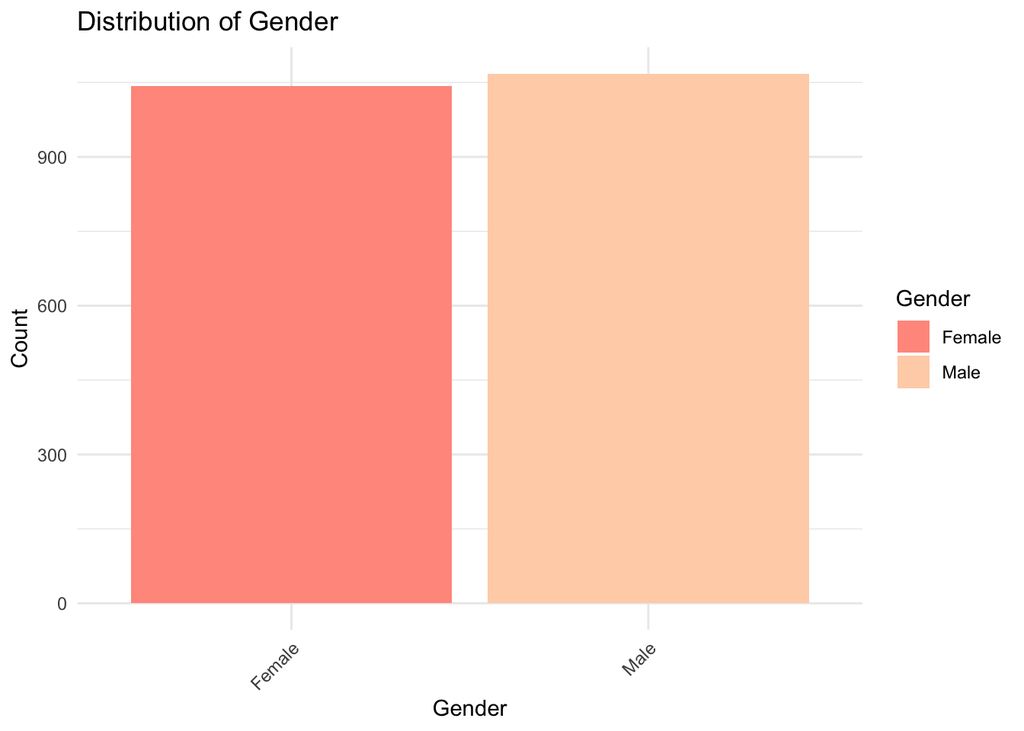

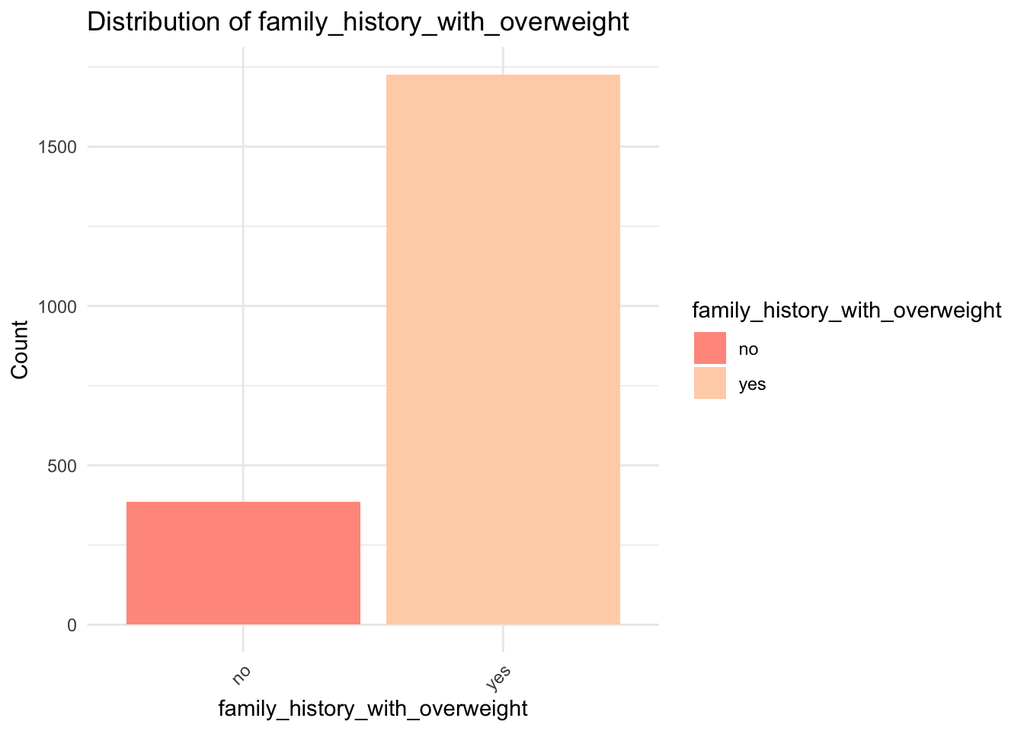

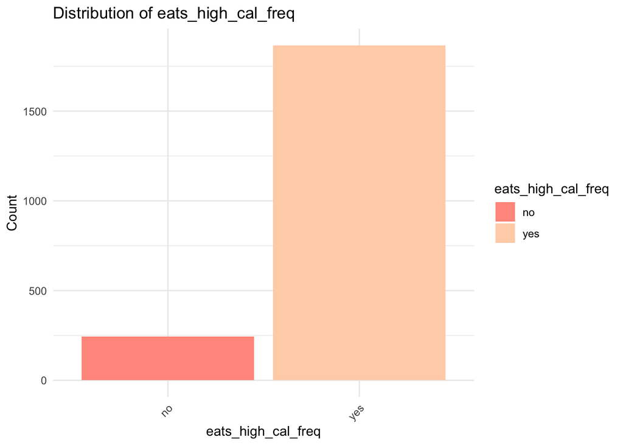

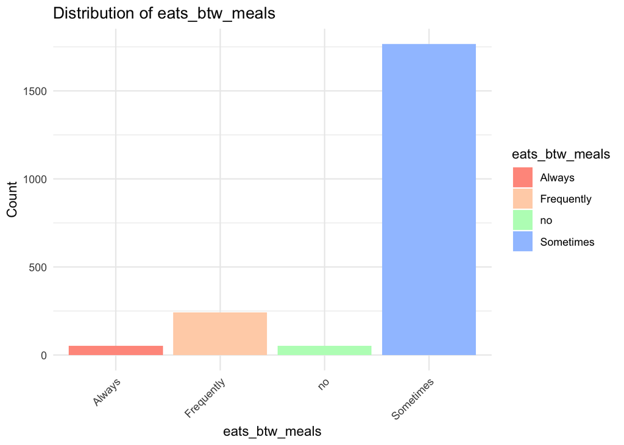

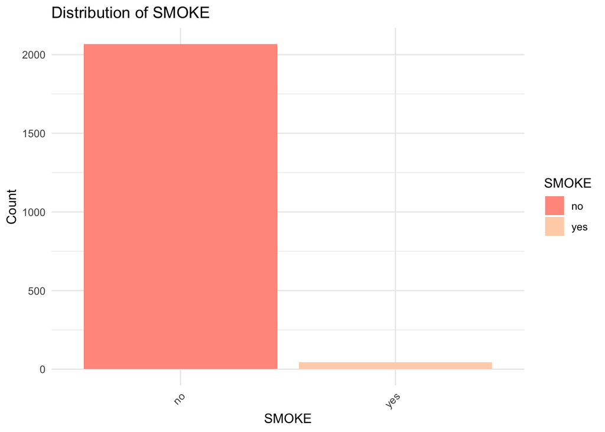

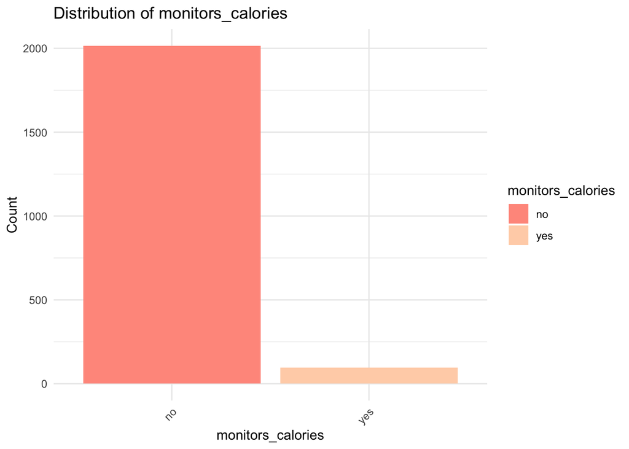

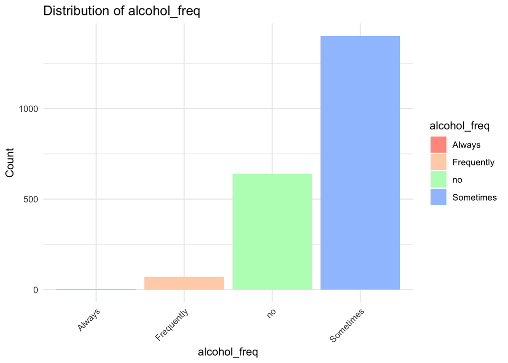

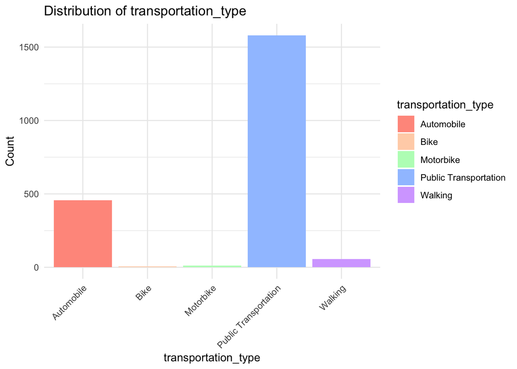

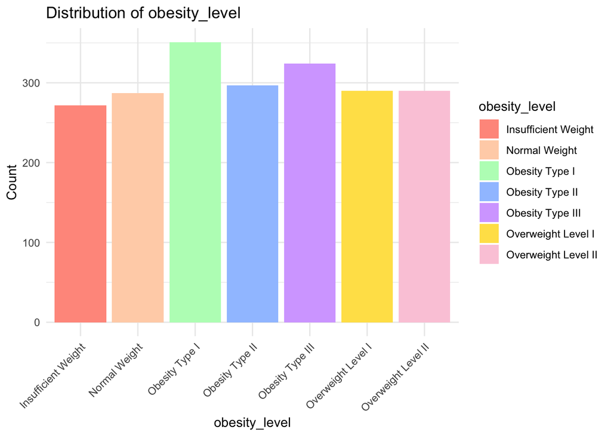

```r
categorical_colors <- c("#FF9A8B", "#FFD3B6", "#B9FBC0", "#A0C4FF",
                        "#D5AAFF", "#FFE156", "#FBCBDB", "#FF677D",
                        "#6FBF9D")

create_bar_plot <- function(data, variable) {
  ggplot(data, aes_string(x = variable, fill = variable)) +
    geom_bar() +
    scale_fill_manual(values = categorical_colors) +
    theme_minimal() +
    labs(title = paste("Distribution of", variable), x = variable, y = "Count") +
    theme(axis.text.x = element_text(angle = 45, hjust = 1))
}

categorical_vars <- c("Gender",
                      "family_history_with_overweight",
                      "eats_high_cal_freq",
                      "eats_btw_meals",
                      "SMOKE",
                      "monitors_calories",
                      "alcohol_freq",
                      "transportation_type",
                      "obesity_level")

for (var in categorical_vars) {
  print(create_bar_plot(data, var))
}
```

##### 3.2.0.2 For continuous variables

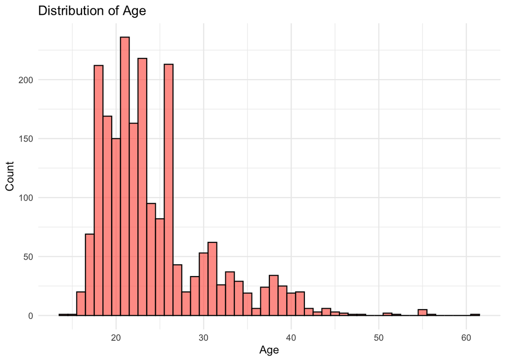

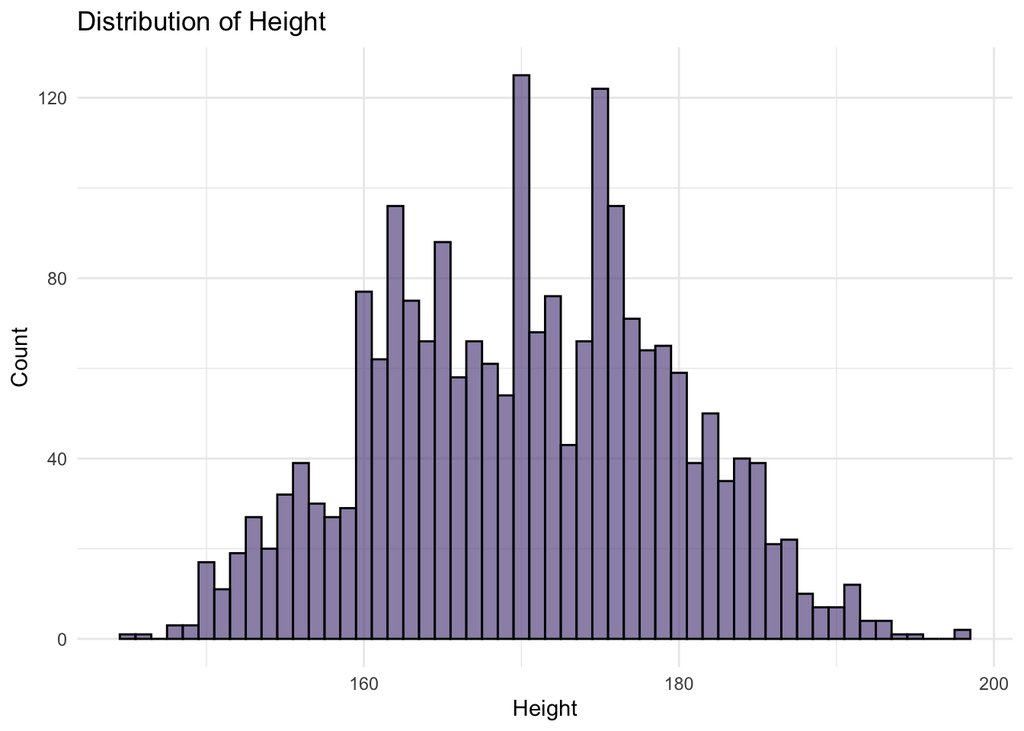

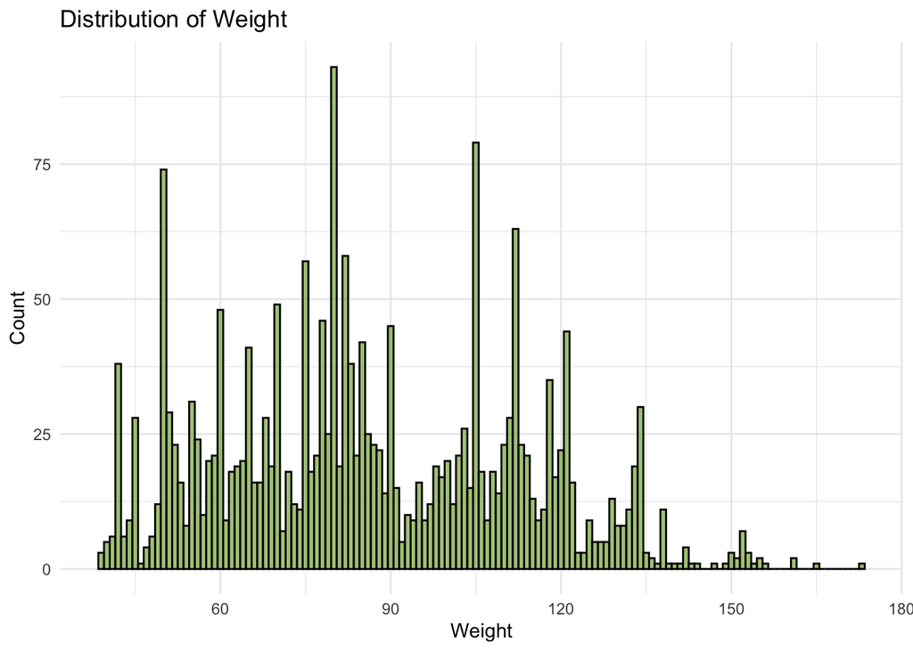

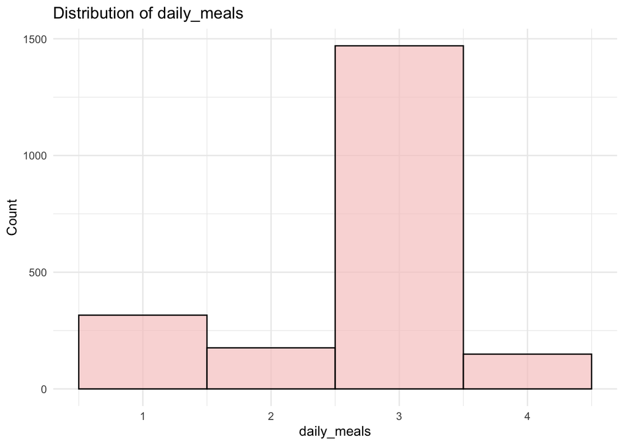

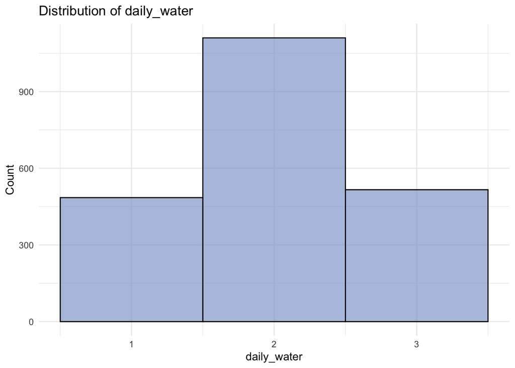

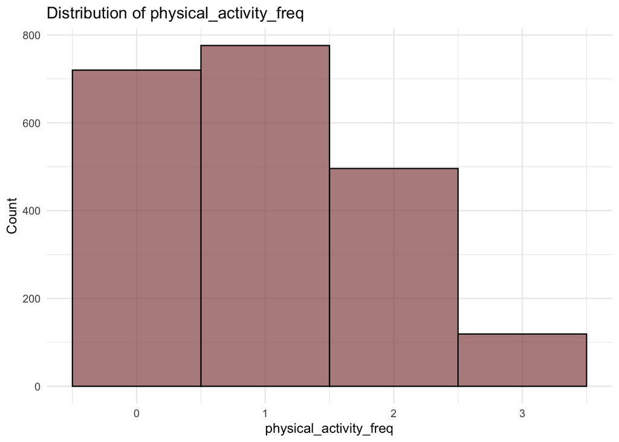

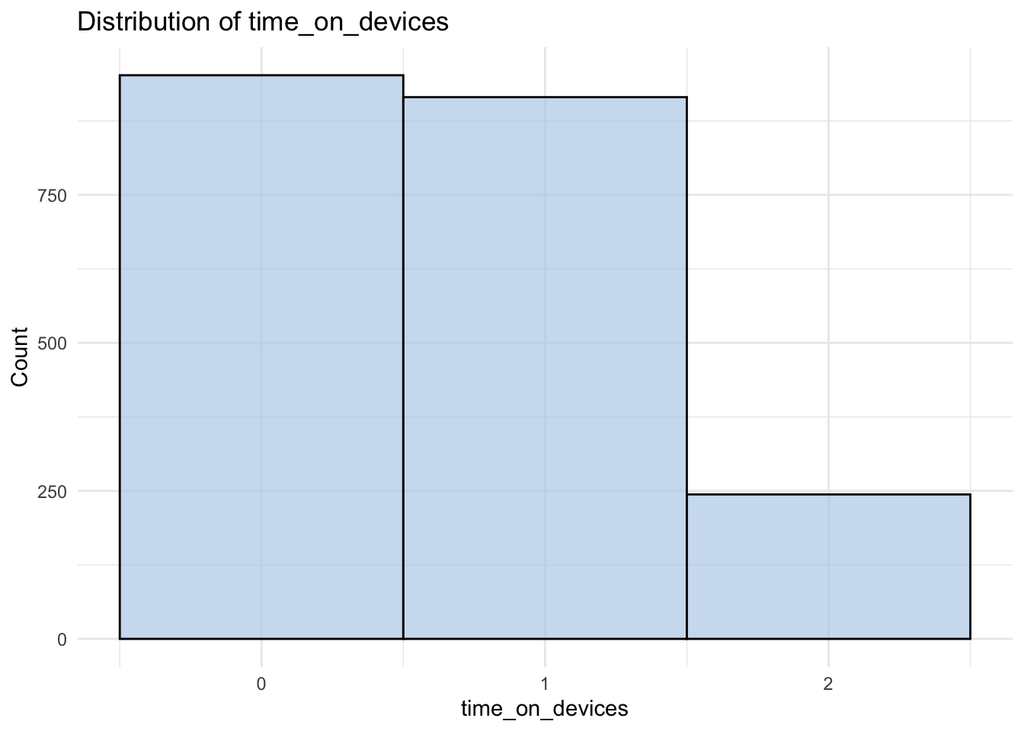

```r
histogram_colors <- c("#FF6F61", "#6B5B93", "#88B04B", "#F7CAC9", "#92A8D1",
                       "#955251", "#B9D1EA")

create_histogram <- function(data, variable) {
  ggplot(data, aes_string(x = variable)) +
    geom_histogram(binwidth = 1, fill = histogram_colors[which(continuous_vars == variable)],
                   color = "black", alpha = 0.7) +
    theme_minimal() +
    labs(title = paste("Distribution of", variable), x = variable, y = "Count")
}

#numeric var list
continuous_vars <- c("Age", "Height", "Weight", "daily_meals",
                     "daily_water", "physical_activity_freq", "time_on_devices")

for (var in continuous_vars) {
  print(create_histogram(data, var))
}
```

```r
data_clean <- read.csv("data_clean.csv")
```

Before getting hands-on with the classification part, I want to convert some of the variables into factors. These variables will be the **binary** and **categorical ones**.

**Namely:**

obesity_level (target variable)

Gender

family_history_with_overweight

eats_high_cal_freq

eats_btw_meals

SMOKE

monitors_calories

alcohol_freq

transportation_type

```r
data_clean$obesity_level <- as.factor(data_clean$obesity_level)

data_clean$Gender <- as.factor(data_clean$Gender)

data_clean$family_history_with_overweight <- as.factor(data_clean$family_history_with_overweight)

data_clean$eats_high_cal_freq <- as.factor(data_clean$eats_high_cal_freq)

data_clean$eats_btw_meals <- as.factor(data_clean$eats_btw_meals)

data_clean$SMOKE <- as.factor(data_clean$SMOKE)

data_clean$monitors_calories <- as.factor(data_clean$monitors_calories)

data_clean$alcohol_freq <- as.factor(data_clean$alcohol_freq)

data_clean$transportation_type <- as.factor(data_clean$transportation_type)
```

One thing I want to do before I move onto the training and testing sets is to combine ‘Overweight I and II’ as well as unify ‘Obesity Level I, II, and III’. Subsequent to this, I will end up having 4 levels in ‘obesity_level’ variable. This is because I believe that combining some of the levels by simplifying those concepts that refer to similar conditions will improve the generalizability power of future models.

I also want to recode obesity_level in a logically ordered way

```r
data_clean$obesity_level <- factor(data_clean$obesity_level,
                                    levels = c("Normal Weight", "Overweight Level I", "Overweight Level II", "Obesity Type I", "Insufficient Weight", "Obesity Type II", "Obesity Type III"),
                                    labels = c("Normal Weight", "Overweight", "Overweight", "Obesity", "Insufficient Weight", "Obesity", "Obesity"))


data_clean$obesity_level <- recode(data_clean$obesity_level,
                                   "Overweight Level I" = "Overweight",
                                   "Overweight Level II" = "Overweight",
                                   "Obesity Type I" = "Obesity",
                                   "Obesity Type II" = "Obesity",
                                   "Obesity Type III" = "Obesity")


obesity_levels <- c("Insufficient Weight", "Normal Weight",
                    "Overweight", "Obesity")

# to have the target variable ordered, will be good for plots

data_clean$obesity_level <- factor(data_clean$obesity_level,
                                    levels = obesity_levels,
                                    ordered = TRUE)
```

## 4 CLASSIFICATION

### 4.1 ANOVA - Numerical variables

```r
numerical_vars <- c("Age", "Height", "Weight", "meals_w_vegetables", "daily_meals",
                    "daily_water", "physical_activity_freq", "time_on_devices")

# ANOVA for each numerical variable vs obesity_level
anova_results <- lapply(numerical_vars, function(var) {
  anova_result <- aov(formula = data_clean[, var] ~ data_clean$obesity_level, data = data_clean)
  summary(anova_result)
})
```

[output not shown]

**Height:** Consistent across levels, with slight increases in spread for higher obesity categories.

**Weight:** Clear increasing trend with obesity level, with distinct medians for each category.

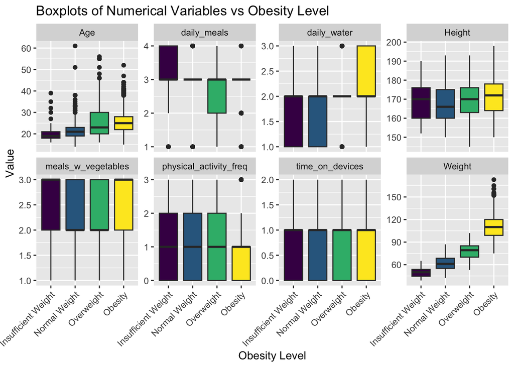

```r
# getting the plot ready
plot_data <- data_clean %>%
  pivot_longer(cols = all_of(numerical_vars), names_to = "Variable", values_to = "Value")

# boxplots for ANOVA results

ggplot(plot_data, aes(x = obesity_level, y = Value, fill = obesity_level)) +
  geom_boxplot() +
  facet_wrap(~ Variable, scales = "free_y", ncol = 4) +
  theme(axis.text.x = element_text(angle = 45, hjust = 1),
        legend.position = "none") +
  labs(title = "Boxplots of Numerical Variables vs Obesity Level",
       x = "Obesity Level", y = "Value")
```

**eats_btw_meals:** “Sometimes” dominates, with slight increases in overweight/obesity levels.

**eats_high_cal_freq:** “yes” is more frequent in overweight and obesity levels, suggesting a link.

**Gender:** “Male” and “Female” distributions vary, with “Male” slightly higher in obesity.

**monitors_calories:** “no” is common across all levels, with minor variation.

**SMOKE:** “no” is dominant, with little difference across levels.

**transportation_type:** “Public Transportation” and “Automobile” are frequent, with “Walking” less common in obesity.

These patterns suggest **family_history_with_overweight** and **eats_high_cal_freq** may be key predictors.

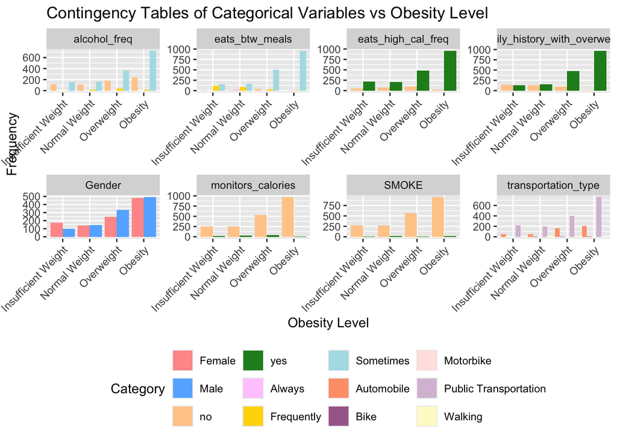

```r
# Categorical variables
categorical_vars <- c("Gender", "family_history_with_overweight", "eats_high_cal_freq",
                      "eats_btw_meals", "SMOKE", "monitors_calories", "alcohol_freq",
                      "transportation_type")

# Create a list to store contingency tables
contingency_list <- lapply(categorical_vars, function(var) {
  table(data_clean[, var], data_clean$obesity_level)
})

# Initialize proper data frame
plot_data_2 <- data.frame()  # Initialize an empty data frame to store results

# Fill the data frame with contingency data
for (i in seq_along(categorical_vars)) {
  temp_df <- as.data.frame(contingency_list[[i]])
  temp_df$Variable <- categorical_vars[i]
  plot_data_2 <- rbind(plot_data_2, temp_df)  # Append rows to the existing data frame
}

# Rename columns for clarity
colnames(plot_data_2) <- c("Category", "Obesity_Level", "Freq", "Variable")


ggplot(plot_data_2, aes(x = Obesity_Level, y = Freq, fill = Category)) +
  geom_bar(stat = "identity", position = "dodge") +
  facet_wrap(~ Variable, scales = "free", ncol = 4) +
  theme(axis.text.x = element_text(angle = 45, hjust = 1),
        legend.position = "bottom") +
  labs(title = "Contingency Tables of Categorical Variables vs Obesity Level",
       x = "Obesity Level", y = "Frequency", fill = "Category") +
  scale_fill_manual(values = c("Female" = "#FF9999",
                               "Male" = "#66B3FF",
                               "yes" = "#228B22",
                               "no" = "#FFCC99",
                               "Always" = "#FFCCFF",
                               "Frequently" = "#FFD700",
                               "Sometimes" = "#B0E0E6",
                               "Automobile" = "#FFA07A",
                               "Bike" = "#A76B9A",
                               "Motorbike" = "#FFE4E1",
                               "Public Transportation" = "#D8BFD8",
                               "Walking" = "#FFFACD"))
```

### 4.3 Training and Testing sets

#### 4.3.1 Splitting

Training set will have 1.690 observations, whereas testing set will have 421.

```r
set.seed(123)

in_train <- createDataPartition(data_clean$obesity_level, p = 0.8, list = FALSE)

training <- data_clean[ in_train,]
testing <- data_clean[-in_train,]

# Check number of rows in both sets
nrow(training)
```

```
[1] 1690
```

```r
nrow(testing)
```

```
[1] 421
```

### 4.4 Multinomial regression

Since the target variable is categorical (with 4 levels), I applied a multinomial regression to examine the influence of various factors on obesity levels. This model helps us understand the relationships between these variables and the likelihood of different obesity statuses.

For this specific model, I included Age, Family History of Overweight, Frequency of Eating High-Calorie Foods, and Frequency of Physical Activity.

Family history with overweight shows a strong positive relationship with obesity, suggesting that individuals with a family history of overweight are more likely to be obese.

Eating high-calorie foods has a strong positive relationship with obesity, indicating that frequent consumption of high-calorie foods increases the likelihood of being classified as obese.

The positive coefficient of age suggests that as individuals grow older, their likelihood of being overweight or obese increases. This could be due to a slowing metabolism over time.

The negative relationship between physical activity and obesity levels indicates that more frequent physical activity reduces the likelihood of being overweight or obese.

```r
multinom_model <- multinom(obesity_level ~ Age + family_history_with_overweight + eats_high_cal_freq +
                             physical_activity_freq, data = training)
summary(multinom_model)
```

```
Call:
multinom(formula = obesity_level ~ Age + family_history_with_overweight +
    eats_high_cal_freq + physical_activity_freq, data = training)

Coefficients:
              (Intercept)       Age family_history_with_overweightyes
Normal Weight   -3.297265 0.1791169                         0.2133399
Overweight      -5.941240 0.2833259                         1.4771027
Obesity        -10.729294 0.2956419                         4.7027060
              eats_high_cal_freqyes physical_activity_freq
Normal Weight           -0.51343372            -0.04115539
Overweight              -0.07459947            -0.30080814
Obesity                  2.15312909            -0.44108487

Std. Errors:
              (Intercept)        Age family_history_with_overweightyes
Normal Weight   0.7236528 0.03310279                         0.1978579
Overweight      0.7040912 0.03151396                         0.2007433
Obesity         0.8639087 0.03163071                         0.4438360
              eats_high_cal_freqyes physical_activity_freq
Normal Weight             0.2321633              0.1045317
Overweight                0.2388168              0.1014772
Obesity                   0.3454667              0.1043594

Residual Deviance: 3388.92
AIC: 3418.92
```

Let’s try to use Age as a quadratic term to capture nonlinear effects before we move on.

In the model, age shows a positive coefficient, meaning that as age increases, the likelihoods of being overweight or obese also increase.

```r
training$Age2 <- training$Age^2
multinom_model_2 <- multinom(obesity_level ~ Age + Age2 + family_history_with_overweight + eats_high_cal_freq + physical_activity_freq, data = training)
summary(multinom_model_2)
```

```
Call:
multinom(formula = obesity_level ~ Age + Age2 + family_history_with_overweight +
    eats_high_cal_freq + physical_activity_freq, data = training)

Coefficients:
              (Intercept)          Age          Age2
Normal Weight  -0.9101308 -0.005841086  0.0032670549
Overweight     -5.5101239  0.254484034  0.0003217663
Obesity       -14.4378072  0.581845938 -0.0051132234
              family_history_with_overweightyes eats_high_cal_freqyes
Normal Weight                          0.283489            -0.5183785
Overweight                             1.538922            -0.0468818
Obesity                                4.639279             2.1181432
              physical_activity_freq
Normal Weight             -0.0564019
Overweight                -0.3037579
Obesity                   -0.3972141

Std. Errors:
              (Intercept)        Age        Age2
Normal Weight  0.01893730 0.03407808 0.001369261
Overweight     0.05451464 0.03465947 0.001367424
Obesity        0.07220583 0.05009308 0.001534808
              family_history_with_overweightyes eats_high_cal_freqyes
Normal Weight                         0.1960368             0.2291735
Overweight                            0.1989676             0.2362567
Obesity                               0.3956121             0.3346415
              physical_activity_freq
Normal Weight              0.1034485
Overweight                 0.1007384
Obesity                    0.1049117

Residual Deviance: 3357.569
AIC: 3393.569
```

To compare model fit with the linear model

The quadratic model has a lower AIC than the linear model,indicating better model fit when including Age2

```r
AIC(multinom_model)  # 3418.92
```

```
[1] 3418.92
```

```r
AIC(multinom_model_2)  # 3393.569
```

```
[1] 3393.569
```

Context for odds ratios:

Odds ratios measure how a predictor affects the odds of an outcome, making it easier to interpret than raw coefficients.

Since logistic and multinomial regression use logarithms of odds, exponentiating the coefficients gives odds ratios, which tells us how much the odds change for a one-unit increase in a variable.

We have used this method during the class, so I want to check exponential coefficients. According to the results:

Age2 suggests that obesity risk first increases with age but may level off or decrease at very high ages.

Family history with overweight strongly influences the likelihood of being classified as Obese, with a much higher coefficient for Obesity compared to other levels.

Eating high-calorie meals also shows a positive relationship with Obesity, while Physical activity frequency negatively impacts the likelihood of being in Obesity or Overweight categories. This indicates that more physical activity reduces the chances of higher obesity levels.

```r
exp(coef(multinom_model_2))
```

```
               (Intercept)       Age      Age2
Normal Weight 4.024716e-01 0.9941759 1.0032724
Overweight    4.045606e-03 1.2897960 1.0003218
Obesity       5.367104e-07 1.7893384 0.9948998
              family_history_with_overweightyes eats_high_cal_freqyes
Normal Weight                          1.327754             0.5954853
Overweight                             4.659562             0.9542002
Obesity                              103.469747             8.3156824
              physical_activity_freq
Normal Weight              0.9451592
Overweight                 0.7380395
Obesity                    0.6721901
```

For easier interpretation

```r
#gg.pred = ggpredict(multinom_model_2, terms = "obesity_level")
#plot(gg.pred)

gg.pred = ggpredict(multinom_model_2, terms = c("Age2", "family_history_with_overweight",
                                                  "eats_high_cal_freq", "physical_activity_freq"),
                    ci_level=NA)
```

```
Data were 'prettified'. Consider using `terms="Age2 [all]"` to get
  smooth plots.
```

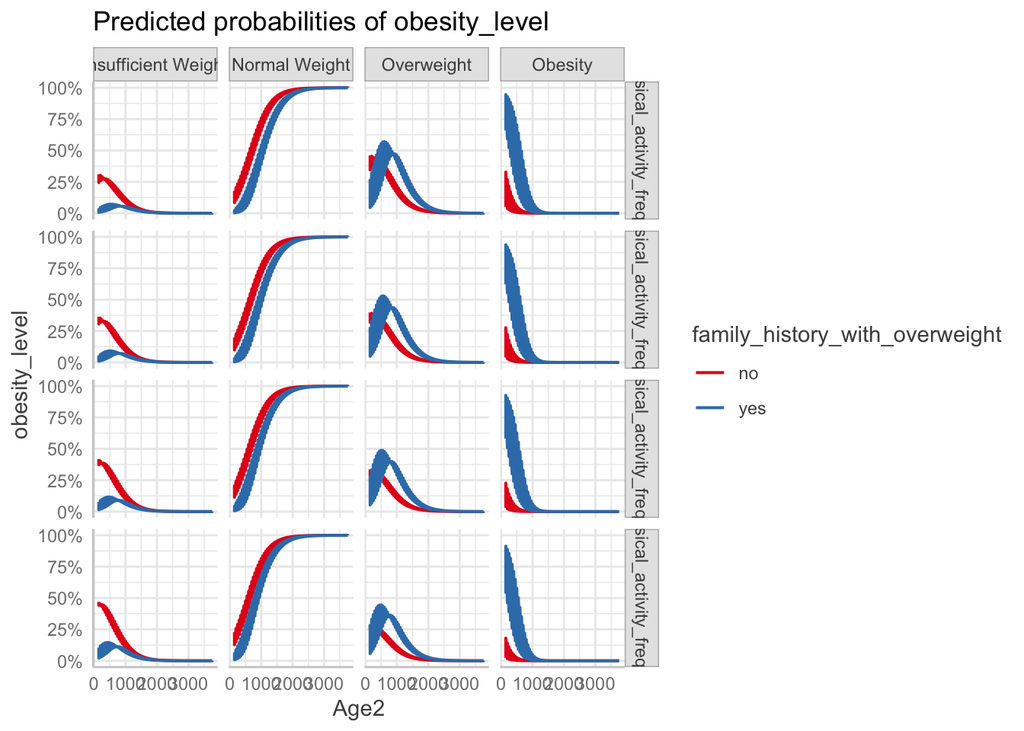

```r
plot(gg.pred)
```

### 4.5 Benchmarking

I want to create a benchmark model to later compare with more complex models. This benchmark model will make predictions on the baseline without using any predictors. It will then predict the **probability** of each level in my target variable. It is worth noting that, during the in-class exercise, we used a binary target variable with ‘Fail’ and ‘Success’ cases. In this task, the target is different, so I will try to adjust my approach accordingly.

```r
set.seed(123)
bench_model <- multinom(obesity_level ~ 1, data = training)
# predicting on the testing set
probability_benchmark <- predict(bench_model, newdata = testing, type = "probs")


obesity_levels <- c("Insufficient Weight", "Normal Weight", "Overweight", "Obesity")

prediction_benchmark <- factor(apply(probability_benchmark, 1, which.max),
                               levels = 1:4, labels = obesity_levels)
head(prediction_benchmark)
```

```
      1      12      18      21      26      27
Obesity Obesity Obesity Obesity Obesity Obesity
Levels: Insufficient Weight Normal Weight Overweight Obesity
```

To check what the benchmark predictions imply:

My dataset has a class imbalance, with Obesity (46%) and Overweight (27%) being more frequent than Normal Weight (13%) and Insufficient Weight (13%). This imbalance could bias my model toward the majority classes, making it less effective at predicting the minority ones.

```r
set.seed(123)
prediction_benchmark <- factor(apply(probability_benchmark, 1, which.max),
                               levels = c("Insufficient Weight", "Normal Weight",
                    "Overweight", "Obesity"))

testing$obesity_level <- factor(testing$obesity_level,
                                levels = c("Insufficient Weight", "Normal Weight",
                    "Overweight", "Obesity"))


# Check if levels match
levels(prediction_benchmark)
```

```
[1] "Insufficient Weight" "Normal Weight"       "Overweight"
[4] "Obesity"
```

```r
levels(testing$obesity_level)
```

```
[1] "Insufficient Weight" "Normal Weight"       "Overweight"
[4] "Obesity"
```

```r
confusionMatrix(prediction_benchmark, testing$obesity_level)$table
```

```
                     Reference
Prediction            Insufficient Weight Normal Weight Overweight Obesity
  Insufficient Weight                   0             0          0       0
  Normal Weight                         0             0          0       0
  Overweight                            0             0          0       0
  Obesity                               0             0          0       0
```

I have found that there is imbalance in my dataset. Let’s try to address it:

```r
dummy_vars <- dummyVars(~ Gender + family_history_with_overweight + eats_high_cal_freq +
                        eats_btw_meals + SMOKE + monitors_calories + alcohol_freq +
                        transportation_type,
                        data = training)

training_numeric <- predict(dummy_vars, newdata = training)


training_numeric <- cbind(training_numeric,
                          training[, c("Age", "Age2", "Height", "Weight", "meals_w_vegetables",
                                       "daily_meals", "daily_water", "physical_activity_freq",
                                       "time_on_devices")])

# to balance out the data

set.seed(123)
smote_result <- SMOTE(X = training_numeric,
                      target = training$obesity_level,
                      K = 5, dup_size = 2)

# extracting the balanced dataset
balanced_training <- smote_result$data

# renaming the target var because smote sees it as 'class'
colnames(balanced_training)[which(colnames(balanced_training) == "class")] <- "obesity_level"

# to make sure obesity_level is a factor with correct levels
balanced_training$obesity_level <- factor(balanced_training$obesity_level,
                                          levels = c("Insufficient Weight", "Normal Weight",
                                                     "Overweight", "Obesity"))
table(balanced_training$obesity_level)
```

```
Insufficient Weight       Normal Weight          Overweight             Obesity
                654                 230                 464                 778
```

### 4.6 Random Forest with / Cros validation

In this step, I trained a Random Forest model using the caret package with 10-fold cross-validation to optimize the mtry parameter and obtain robust performance estimates.

The Random Forest model achieves a high accuracy of 0.9412 (mtry = 5), showing strong performance across the four obesity classes.

The Kappa of 0.9173 indicates excellent agreement beyond chance, while the Mean_F1 score of 0.9121 and Mean_Sensitivity of 0.9086 suggest balanced and robust predictions, despite potential challenges with the underrepresented Normal_Weight class.

```r
set.seed(123)

# rename levels of obesity_level to be valid R variable names
levels(balanced_training$obesity_level) <- c("Insufficient_Weight", "Normal_Weight", "Overweight", "Obesity")
levels(testing$obesity_level) <- c("Insufficient_Weight", "Normal_Weight", "Overweight", "Obesity")

# for 10-fold cross-validation
ctrl <- trainControl(method = "cv", number = 10, classProbs = TRUE,
                     summaryFunction = multiClassSummary, verboseIter = TRUE)

# training Random Forest using caret
rf_caret <- train(obesity_level ~ family_history_with_overweight.yes + eats_high_cal_freq.yes +
                  physical_activity_freq + Weight + Age + Gender.Male +
                  eats_btw_meals.Sometimes + alcohol_freq.Sometimes,
                  data = balanced_training,
                  method = "rf",
                  tuneLength = 5,
                  metric = "Accuracy",
                  trControl = ctrl)
print(rf_caret)
```

```
Random Forest

2126 samples
   8 predictor
   4 classes: 'Insufficient_Weight', 'Normal_Weight', 'Overweight', 'Obesity'

No pre-processing
Resampling: Cross-Validated (10 fold)
Summary of sample sizes: 1912, 1913, 1915, 1914, 1913, 1915, ...
Resampling results across tuning parameters:

  mtry  logLoss    AUC        prAUC      Accuracy   Kappa      Mean_F1
  2     0.2607859  0.9876516  0.8125745  0.9214265  0.8891825  0.8829719
  3     0.1976457  0.9904149  0.7457150  0.9379075  0.9126428  0.9071033
  5     0.1811491  0.9902712  0.6133800  0.9411917  0.9172792  0.9120719
  6     0.2071289  0.9896418  0.5887995  0.9388487  0.9139245  0.9083676
  8     0.2742487  0.9878829  0.5271506  0.9327188  0.9052418  0.8988290
  Mean_Sensitivity  Mean_Specificity  Mean_Pos_Pred_Value  Mean_Neg_Pred_Value
  0.8756292         0.9739939         0.9018350            0.9751963
  0.9032278         0.9798363         0.9164629            0.9803076
  0.9086054         0.9808848         0.9180540            0.9813978
  0.9037199         0.9800301         0.9159463            0.9807215
  0.8940669         0.9779589         0.9065268            0.9788584
  Mean_Precision  Mean_Recall  Mean_Detection_Rate  Mean_Balanced_Accuracy
  0.9018350       0.8756292    0.2303566            0.9248115
  0.9164629       0.9032278    0.2344769            0.9415320
  0.9180540       0.9086054    0.2352979            0.9447451
  0.9159463       0.9037199    0.2347122            0.9418750
  0.9065268       0.8940669    0.2331797            0.9360129

Accuracy was used to select the optimal model using the largest value.
The final value used for the model was mtry = 5.
```

#### 4.6.1 Adjusting the prediction threshold

Let’s now try to adjust the prediction threshold for the Random Forest model to improve performance on minority classes (Normal_Weight, Insufficient_Weight) by prioritizing their probabilities.

The threshold adjustment (0.3) for minority classes results in a very low accuracy of 0.247 and a negative Kappa of -0.0643, indicating poor overall performance.

Sensitivity for Insufficient_Weight (0.8519) and Normal_Weight (0.8246) is decent, showing improved detection of these minority classes, but Sensitivity for Overweight (0.0259) and Obesity (0.0412) is extremely low, meaning the model fails to predict the majority classes effectively.

```r
set.seed(123)

#test set with dummy variables
dummy_vars <- dummyVars(~ Gender + family_history_with_overweight + eats_high_cal_freq +
                        eats_btw_meals + SMOKE + monitors_calories + alcohol_freq +
                        transportation_type,
                        data = testing)

# dummy variable transformation to testing set
testing_numeric <- predict(dummy_vars, newdata = testing)

testing_numeric <- cbind(testing_numeric,
                         testing[, c("Age", "Height", "Weight", "meals_w_vegetables",
                                     "daily_meals", "daily_water", "physical_activity_freq",
                                     "time_on_devices")])

testing_subset <- as.data.frame(testing_numeric)
testing_subset <- testing_subset[, c("family_history_with_overweight.yes", "eats_high_cal_freq.yes",
                                     "physical_activity_freq", "Weight", "Age", "Gender.Male",
                                     "eats_btw_meals.Sometimes", "alcohol_freq.Sometimes")]
testing_subset$obesity_level <- testing$obesity_level
rf_prob <- predict(rf_caret, newdata = testing_subset, type = "prob")

# adjusting the threshold to 0.3
threshold <- 0.3
prediction <- as.factor(apply(rf_prob, 1, function(x) {
  if (x["Normal_Weight"] > threshold || x["Insufficient_Weight"] > threshold) {
    names(which.max(x[c("Normal_Weight", "Insufficient_Weight")]))
  } else {
    names(which.max(x))
  }
}))

levels(prediction) <- levels(testing$obesity_level)

cm_threshold <- confusionMatrix(prediction, testing$obesity_level)
print(cm_threshold)
```

```
Confusion Matrix and Statistics

                     Reference
Prediction            Insufficient_Weight Normal_Weight Overweight Obesity
  Insufficient_Weight                  46             4          0       0
  Normal_Weight                         8            47          4       0
  Overweight                            0             0          3     186
  Obesity                               0             6        109       8

Overall Statistics

               Accuracy : 0.247
                 95% CI : (0.2065, 0.2911)
    No Information Rate : 0.4608
    P-Value [Acc > NIR] : 1

                  Kappa : -0.0643

 Mcnemar's Test P-Value : NA

Statistics by Class:

                     Class: Insufficient_Weight Class: Normal_Weight
Sensitivity                              0.8519               0.8246
Specificity                              0.9891               0.9670
Pos Pred Value                           0.9200               0.7966
Neg Pred Value                           0.9784               0.9724
Prevalence                               0.1283               0.1354
Detection Rate                           0.1093               0.1116
Detection Prevalence                     0.1188               0.1401
Balanced Accuracy                        0.9205               0.8958
                     Class: Overweight Class: Obesity
Sensitivity                   0.025862        0.04124
Specificity                   0.390164        0.49339
Pos Pred Value                0.015873        0.06504
Neg Pred Value                0.512931        0.37584
Prevalence                    0.275534        0.46081
Detection Rate                0.007126        0.01900
Detection Prevalence          0.448931        0.29216
Balanced Accuracy             0.208013        0.26731
```

#### 4.6.2 Variable Importance Plots

I’m a bit disappointed but let’s create the ‘Variable Importance’ plots for better interpretation

The variable importance plot for the Random Forest model shows ‘Weight’ as the most influential predictor for classifying obesity_level, followed by ‘Age’ and ‘family_history_with_overweight.yes.’ ‘Gender.Male’, ‘physical_activity_freq’, ‘eats_btw_meals.Sometimes’, ‘alcohol_freq.Sometimes’, and ‘eats_high_cal_freq.yes’ have progressively less importance, indicating they contribute less to the model’s decisions.

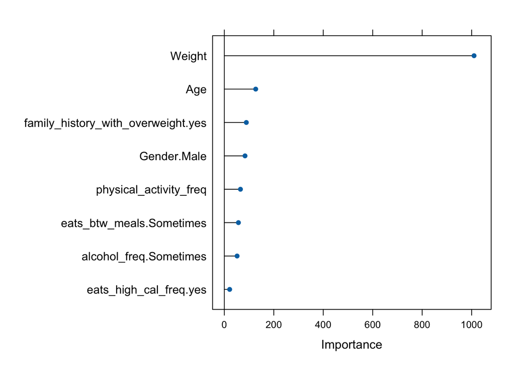

```r
rf_imp <- varImp(rf_caret, scale = FALSE)
plot(rf_imp, scales = list(y = list(cex = 0.95)))
```

#### 4.6.3 Partial Dependence Plots (PDPs)

To see the key predictors, we can take a look at partial dependence plots

For instance:

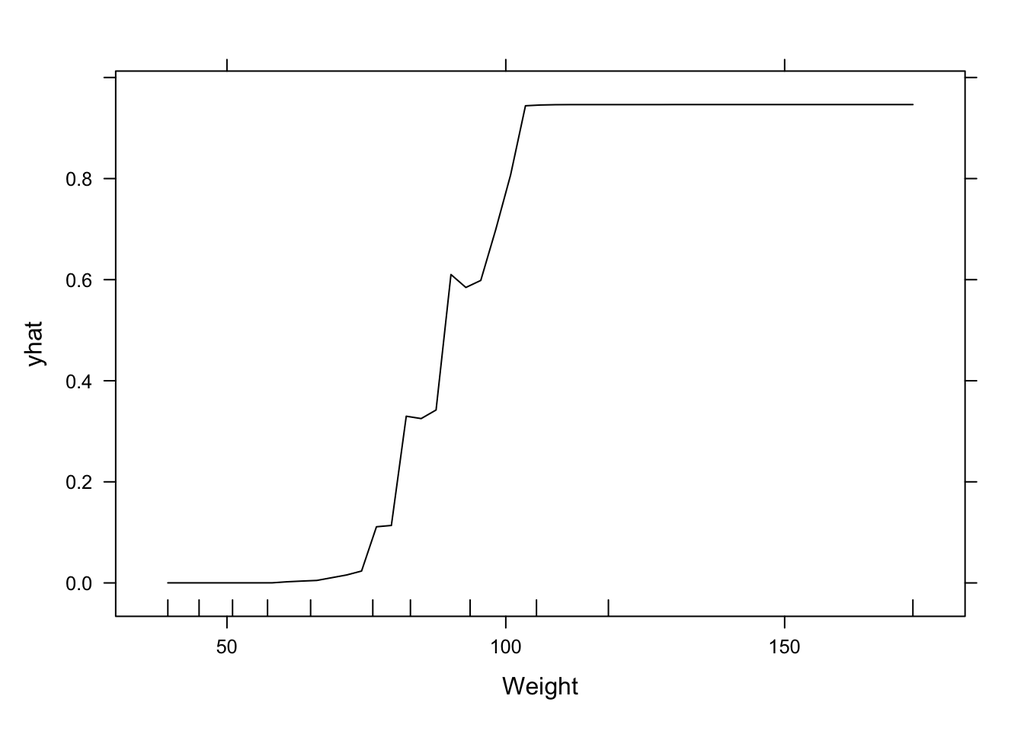

```r
pdp_weight <- partial(rf_caret, pred.var = "Weight", which.class = "Obesity",
                      plot = TRUE, prob = TRUE, rug = TRUE)
pdp_family_history <- partial(rf_caret, pred.var = "family_history_with_overweight.yes",
                              which.class = "Obesity", plot = TRUE, prob = TRUE, rug = TRUE)

print(pdp_weight)
```

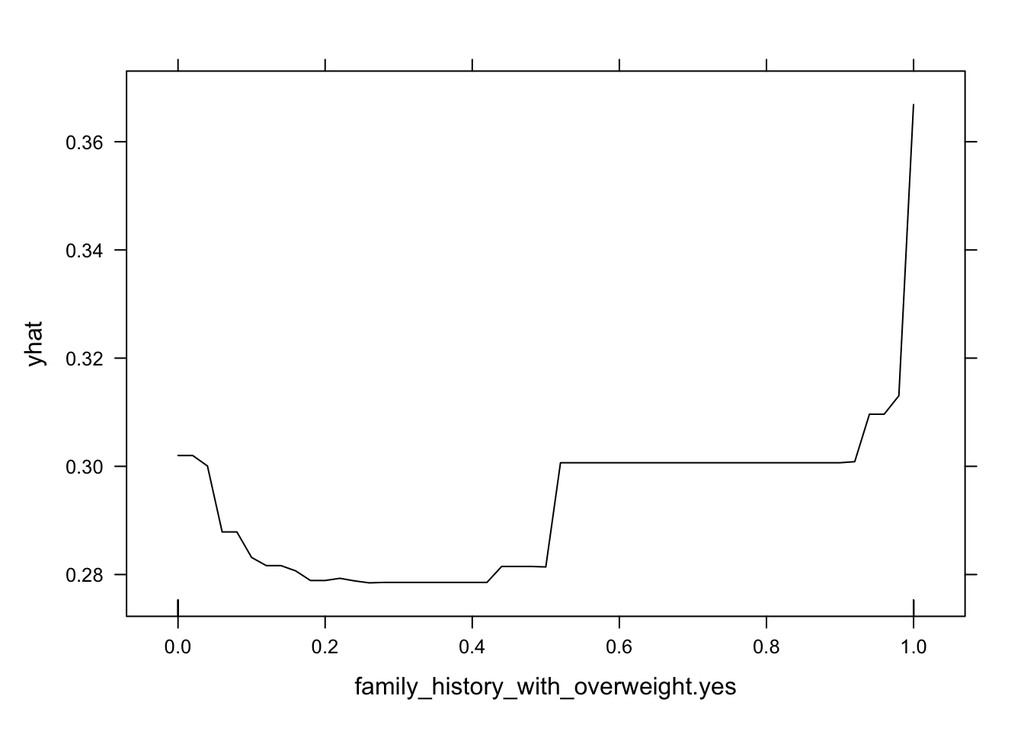

```r
print(pdp_family_history)
```

### 4.7 QDA

As per our class notes, LDA performs better for more than two groups if predictors are somewhat Gaussian. So, I think that Linear Discriminant Analysis (LDA) could be a good starting point.

Age2 was added to capture non-linear effects earlier, but since it’s causing issues (rank deficiency), I’ll drop it and let QDA handle non-linearity through its own flexibility

Also, I’ll need to eliminate some of the dummy variables that were created earlier, because QDA model is not able to work with the variances and yield results.

The QDA model shows prior probabilities reflecting the balanced training data: Obesity (36.6%) and Insufficient_Weight (30.8%) are the largest groups, while Normal_Weight (10.8%) is the smallest.

Group means indicate that Obesity has the highest family_history_with_overweight.yes (99.2%), eats_high_cal_freq.yes (98.1%), and Weight (108.5), and the lowest physical_activity_freq (0.87), while Insufficient_Weight has the lowest Weight (49.99) and highest physical_activity_freq (1.26), highlighting clear distinctions in predictors across classes.

```r
balanced_training$Age2 <- NULL

near_zero <- nearZeroVar(balanced_training, saveMetrics = TRUE)
print(near_zero)
```

```
                                           freqRatio percentUnique zeroVar
Gender.Female                               1.136691    2.30479774   FALSE
Gender.Male                                 1.136691    2.30479774   FALSE
family_history_with_overweight.no           2.965583    2.53998119   FALSE
family_history_with_overweight.yes          2.965583    2.53998119   FALSE
eats_high_cal_freq.no                       7.094488    3.38664158   FALSE
eats_high_cal_freq.yes                      7.094488    3.38664158   FALSE
eats_btw_meals.Always                      45.152174    0.23518344   FALSE
eats_btw_meals.Frequently                   4.423280    3.66886171   FALSE
eats_btw_meals.no                          56.216216    0.51740357   FALSE
eats_btw_meals.Sometimes                    3.369427    3.29256820   FALSE
SMOKE.no                                   61.529412    0.09407338   FALSE
SMOKE.yes                                  61.529412    0.09407338   FALSE
monitors_calories.no                       17.812500    0.98777046   FALSE
monitors_calories.yes                      17.812500    0.98777046   FALSE
alcohol_freq.Always                         0.000000    0.04703669    TRUE
alcohol_freq.Frequently                    34.383333    0.23518344   FALSE
alcohol_freq.no                             1.969914    2.58701787   FALSE
alcohol_freq.Sometimes                      1.730871    2.72812794   FALSE
transportation_type.Automobile              3.943396    1.50517404   FALSE
transportation_type.Bike                  424.200000    0.09407338   FALSE
transportation_type.Motorbike             211.600000    0.09407338   FALSE
transportation_type.Public Transportation   3.311340    1.74035748   FALSE
transportation_type.Walking                48.186047    0.61147695   FALSE
Age                                         1.073593    2.68109125   FALSE
Height                                      1.091837   17.73283161   FALSE
Weight                                      1.113208   45.76669802   FALSE
meals_w_vegetables                          1.165517    6.96142992   FALSE
daily_meals                                 4.110063    7.00846660   FALSE
daily_water                                 2.020243    8.60771402   FALSE
physical_activity_freq                      1.010736    8.04327375   FALSE
time_on_devices                             1.043326    7.10253998   FALSE
obesity_level                               1.189602    0.18814675   FALSE
                                            nzv
Gender.Female                             FALSE
Gender.Male                               FALSE
family_history_with_overweight.no         FALSE
family_history_with_overweight.yes        FALSE
eats_high_cal_freq.no                     FALSE
eats_high_cal_freq.yes                    FALSE
```

[output cut: 11 more lines]

```
alcohol_freq.Sometimes                    FALSE
transportation_type.Automobile            FALSE
transportation_type.Bike                   TRUE
transportation_type.Motorbike              TRUE
transportation_type.Public Transportation FALSE
transportation_type.Walking                TRUE
Age                                       FALSE
Height                                    FALSE
Weight                                    FALSE
meals_w_vegetables                        FALSE
daily_meals                               FALSE
daily_water                               FALSE
physical_activity_freq                    FALSE
time_on_devices                           FALSE
obesity_level                             FALSE
```

```r
if (any(near_zero$nzv)) {
  balanced_training <- balanced_training[, !near_zero$nzv]
}


testing_numeric <- predict(dummy_vars, newdata = testing)
testing_numeric <- cbind(testing_numeric,
                         testing[, c("Age", "Height", "Weight", "meals_w_vegetables",
                                     "daily_meals", "daily_water", "physical_activity_freq",
                                     "time_on_devices")])

testing_subset <- as.data.frame(testing_numeric)
testing_subset <- testing_subset[, c("family_history_with_overweight.yes", "eats_high_cal_freq.yes",
                                     "physical_activity_freq", "Weight", "Age", "Gender.Male",
                                     "eats_btw_meals.Sometimes", "alcohol_freq.Sometimes")]
testing_subset$obesity_level <- testing$obesity_level


qda_model <- qda(obesity_level ~ family_history_with_overweight.yes + eats_high_cal_freq.yes +
                 physical_activity_freq + Weight + Age + Gender.Male +
                 eats_btw_meals.Sometimes + alcohol_freq.Sometimes,
                 data = balanced_training)

print(qda_model)
```

```
Call:
qda(obesity_level ~ family_history_with_overweight.yes + eats_high_cal_freq.yes +
    physical_activity_freq + Weight + Age + Gender.Male + eats_btw_meals.Sometimes +
    alcohol_freq.Sometimes, data = balanced_training)

Prior probabilities of groups:
Insufficient_Weight       Normal_Weight          Overweight             Obesity
          0.3076199           0.1081844           0.2182502           0.3659454

Group means:
                    family_history_with_overweight.yes eats_high_cal_freq.yes
Insufficient_Weight                          0.4576604              0.8044219
Normal_Weight                                0.5347826              0.7173913
Overweight                                   0.8254310              0.8318966
Obesity                                      0.9922879              0.9807198
                    physical_activity_freq    Weight      Age Gender.Male
Insufficient_Weight              1.2583726  49.99121 19.77910   0.3551293
Normal_Weight                    1.2347826  61.68130 21.68261   0.4782609
Overweight                       0.9935345  78.11487 25.19181   0.5840517
Obesity                          0.8701799 108.49807 25.70694   0.4961440
                    eats_btw_meals.Sometimes alcohol_freq.Sometimes
Insufficient_Weight                0.5111424              0.5301451
Normal_Weight                      0.5347826              0.5521739
Overweight                         0.8663793              0.6400862
Obesity                            0.9794344              0.7300771
```

First things first, since I realised that there is imbalance in the data after splitting the training and testing sets, I need to apply insert dummy variables into my test set in order to match other sets and compare model performances.

```r
set.seed(123)

dummy_vars_train <- dummyVars(~ Gender + family_history_with_overweight + eats_high_cal_freq +
                              eats_btw_meals + SMOKE + monitors_calories + alcohol_freq +
                              transportation_type,
                              data = training)

training_numeric <- predict(dummy_vars_train, newdata = training)
training_numeric <- cbind(training_numeric,
                          training[, c("Age", "Height", "Weight", "meals_w_vegetables",
                                       "daily_meals", "daily_water", "physical_activity_freq",
                                       "time_on_devices")])

training_subset <- as.data.frame(training_numeric)
training_subset$obesity_level <- training$obesity_level

# first, retraining multinom_model_2 without Age2, becuase I removed it
multinom_model_2 <- multinom(obesity_level ~ family_history_with_overweight.yes + eats_high_cal_freq.yes +
                             physical_activity_freq + Weight + Age + Gender.Male +
                             eats_btw_meals.Sometimes + alcohol_freq.Sometimes,
                             data = training_subset)
summary(multinom_model_2)
```

```
Call:
multinom(formula = obesity_level ~ family_history_with_overweight.yes +
    eats_high_cal_freq.yes + physical_activity_freq + Weight +
    Age + Gender.Male + eats_btw_meals.Sometimes + alcohol_freq.Sometimes,
    data = training_subset)

Coefficients:
              (Intercept) family_history_with_overweight.yes
Normal Weight   -20.33609                         -0.9873957
Overweight      -39.29981                         -1.3710726
Obesity         -70.81418                          0.1413792
              eats_high_cal_freq.yes physical_activity_freq    Weight
Normal Weight             -0.7956526             -0.5652633 0.3907727
Overweight                -0.6208867             -1.1770106 0.6809106
Obesity                   -0.4346591             -1.4446475 1.0421806
                     Age Gender.Male eats_btw_meals.Sometimes
Normal Weight 0.07708873   -2.687800                0.3201464
Overweight    0.09424100   -5.530292                1.4470293
Obesity       0.12362079  -10.361013                2.4213489
              alcohol_freq.Sometimes
Normal Weight              0.5989349
Overweight                 1.5590918
Obesity                    1.0863694

Std. Errors:
              (Intercept) family_history_with_overweight.yes
Normal Weight    2.152192                          0.3726978
Overweight       2.724245                          0.4707383
Obesity          3.796534                          0.9129734
              eats_high_cal_freq.yes physical_activity_freq     Weight
Normal Weight              0.4066878              0.1725223 0.03892794
Overweight                 0.5049349              0.2267575 0.04746491
Obesity                    0.7428392              0.2624475 0.05578640
                     Age Gender.Male eats_btw_meals.Sometimes
Normal Weight 0.04500560   0.4533594                0.3238274
Overweight    0.04961346   0.6055984                0.4293051
Obesity       0.05209407   0.7507683                0.7139408
              alcohol_freq.Sometimes
Normal Weight              0.3205138
Overweight                 0.4237851
Obesity                    0.4924893

Residual Deviance: 1150.419
AIC: 1204.419
```

```r
# test set with dummy variables
dummy_vars <- dummyVars(~ Gender + family_history_with_overweight + eats_high_cal_freq +
                        eats_btw_meals + SMOKE + monitors_calories + alcohol_freq +
                        transportation_type,
                        data = testing)

# dummy variable transformation to testing set
testing_numeric <- predict(dummy_vars, newdata = testing)

testing_numeric <- cbind(testing_numeric,
                         testing[, c("Age", "Height", "Weight", "meals_w_vegetables",
                                     "daily_meals", "daily_water", "physical_activity_freq",
                                     "time_on_devices")])

testing_subset <- as.data.frame(testing_numeric)
testing_subset <- testing_subset[, c("family_history_with_overweight.yes", "eats_high_cal_freq.yes",
                                     "physical_activity_freq", "Weight", "Age", "Gender.Male",
                                     "eats_btw_meals.Sometimes", "alcohol_freq.Sometimes")]

testing_subset$obesity_level <- testing$obesity_level
```

Let’s make the predictions

```r
qda_pred <- predict(qda_model, newdata = testing_subset)$class
rf_pred <- predict(rf_caret, newdata = testing_subset)
multinom_pred <- predict(multinom_model_2, newdata = testing_subset, type = "class")
```

#### 4.7.1 Model comparison

QDA has an accuracy of 0.772 and a Kappa of 0.652, showing moderate performance but struggling with minority classes like Normal_Weight (Sensitivity 0.6667).  
Random Forest outperforms with an accuracy of 0.9145 and a Kappa of 0.8735, indicating excellent overall prediction and strong handling of class imbalance across all classes.  
Logistic Regression performs poorly, with an accuracy of 0.8459 and a Kappa of 0.6855, failing to predict minority classes like Insufficient_Weight and Normal_Weight (Sensitivity 0).  
Random Forest is the best, with the highest accuracy (0.9145) and Kappa (0.8735), making it the strongest for prediction due to its ability to handle imbalanced data and complex relationships.

```r
qda_cm <- confusionMatrix(qda_pred, testing_subset$obesity_level)
rf_cm <- confusionMatrix(rf_pred, testing_subset$obesity_level)

# Ensure multinom_pred levels match testing_subset$obesity_level
multinom_pred <- factor(multinom_pred, levels = levels(testing_subset$obesity_level))
logit_cm <- confusionMatrix(multinom_pred, testing_subset$obesity_level)

print("QDA Confusion Matrix:")
```

```
[1] "QDA Confusion Matrix:"
```

```r
print(qda_cm)
```

```
Confusion Matrix and Statistics

                     Reference
Prediction            Insufficient_Weight Normal_Weight Overweight Obesity
  Insufficient_Weight                  47             6          0       0
  Normal_Weight                         6            38         10       1
  Overweight                            1             9         55       8
  Obesity                               0             4         51     185

Overall Statistics

               Accuracy : 0.772
                 95% CI : (0.7289, 0.8112)
    No Information Rate : 0.4608
    P-Value [Acc > NIR] : < 2.2e-16

                  Kappa : 0.6522

 Mcnemar's Test P-Value : NA

Statistics by Class:

                     Class: Insufficient_Weight Class: Normal_Weight
Sensitivity                              0.8704              0.66667
Specificity                              0.9837              0.95330
Pos Pred Value                           0.8868              0.69091
Neg Pred Value                           0.9810              0.94809
Prevalence                               0.1283              0.13539
Detection Rate                           0.1116              0.09026
Detection Prevalence                     0.1259              0.13064
Balanced Accuracy                        0.9270              0.80998
                     Class: Overweight Class: Obesity
Sensitivity                     0.4741         0.9536
Specificity                     0.9410         0.7577
Pos Pred Value                  0.7534         0.7708
Neg Pred Value                  0.8247         0.9503
Prevalence                      0.2755         0.4608
Detection Rate                  0.1306         0.4394
Detection Prevalence            0.1734         0.5701
Balanced Accuracy               0.7076         0.8557
```

```r
print("Random Forest Confusion Matrix:")
```

```
[1] "Random Forest Confusion Matrix:"
```

```r
print(rf_cm)
```

```
Confusion Matrix and Statistics

                     Reference
Prediction            Insufficient_Weight Normal_Weight Overweight Obesity
  Insufficient_Weight                  46             4          0       0
  Normal_Weight                         8            42          2       0
  Overweight                            0            11        111       8
  Obesity                               0             0          3     186

Overall Statistics

               Accuracy : 0.9145
                 95% CI : (0.8836, 0.9394)
    No Information Rate : 0.4608
    P-Value [Acc > NIR] : < 2.2e-16

                  Kappa : 0.8735

 Mcnemar's Test P-Value : NA

Statistics by Class:

                     Class: Insufficient_Weight Class: Normal_Weight
Sensitivity                              0.8519              0.73684
Specificity                              0.9891              0.97253
Pos Pred Value                           0.9200              0.80769
Neg Pred Value                           0.9784              0.95935
Prevalence                               0.1283              0.13539
Detection Rate                           0.1093              0.09976
Detection Prevalence                     0.1188              0.12352
Balanced Accuracy                        0.9205              0.85468
                     Class: Overweight Class: Obesity
Sensitivity                     0.9569         0.9588
Specificity                     0.9377         0.9868
Pos Pred Value                  0.8538         0.9841
Neg Pred Value                  0.9828         0.9655
Prevalence                      0.2755         0.4608
Detection Rate                  0.2637         0.4418
Detection Prevalence            0.3088         0.4489
Balanced Accuracy               0.9473         0.9728
```

```r
print("Multinomial Multinom Regression Confusion Matrix:")
```

```
[1] "Multinomial Multinom Regression Confusion Matrix:"
```

```r
print(logit_cm)
```

```
Confusion Matrix and Statistics

                     Reference
Prediction            Insufficient_Weight Normal_Weight Overweight Obesity
  Insufficient_Weight                   0             0          0       0
  Normal_Weight                         0             0          0       0
  Overweight                            0            18         86      11
  Obesity                               0             0         20     183

Overall Statistics

               Accuracy : 0.8459
                 95% CI : (0.8015, 0.8838)
    No Information Rate : 0.6101
    P-Value [Acc > NIR] : < 2.2e-16

                  Kappa : 0.6855

 Mcnemar's Test P-Value : NA

Statistics by Class:

                     Class: Insufficient_Weight Class: Normal_Weight
Sensitivity                                  NA               0.0000
Specificity                                   1               1.0000
Pos Pred Value                               NA                  NaN
Neg Pred Value                               NA               0.9434
Prevalence                                    0               0.0566
Detection Rate                                0               0.0000
Detection Prevalence                          0               0.0000
Balanced Accuracy                            NA               0.5000
                     Class: Overweight Class: Obesity
Sensitivity                     0.8113         0.9433
Specificity                     0.8632         0.8387
Pos Pred Value                  0.7478         0.9015
Neg Pred Value                  0.9015         0.9043
Prevalence                      0.3333         0.6101
Detection Rate                  0.2704         0.5755
Detection Prevalence            0.3616         0.6384
Balanced Accuracy               0.8373         0.8910
```

```r
# for a much clearer layout, this will help us decide the best model easily
cat("QDA Accuracy:", qda_cm$overall["Accuracy"], "\n")
```

```
QDA Accuracy: 0.7719715
```

```r
cat("QDA Kappa:", qda_cm$overall["Kappa"], "\n")
```

```
QDA Kappa: 0.6522338
```

```r
cat("Random Forest Accuracy:", rf_cm$overall["Accuracy"], "\n")
```

```
Random Forest Accuracy: 0.9144893
```

```r
cat("Random Forest Kappa:", rf_cm$overall["Kappa"], "\n")
```

```
Random Forest Kappa: 0.8735219
```

```r
cat("Logistic Regression Accuracy:", logit_cm$overall["Accuracy"], "\n")
```

```
Logistic Regression Accuracy: 0.8459119
```

```r
cat("Logistic Regression Kappa:", logit_cm$overall["Kappa"], "\n")
```

```
Logistic Regression Kappa: 0.6855425
```

## 5 ADVANCED REGRESSION

For regression, I will need a numerical target variable. In the dataset, obesity_level is categorical (with 4 levels), so I’ll need to select or create a numerical target.

Based on the dataset, ‘Weight’ is a suitable numerical variable for regression, as it’s directly related to obesity and aligns with the focus of this study regardion eating habits and physical condition.

### 5.1 Linear regression

Let’s fit a linear regression model to predict Weight using key predictors and focus on understanding their impact.

**Results**

**Most Important Variables (in order of impact based on coefficient magnitude):**

The most important variables influencing Weight in the linear regression model are family_history_with_overweightyes, which significantly increases Weight when there’s a family history of overweight, followed by transportation_typePublic Transportation and eats_btw_mealsSometimes, both of which are associated with higher Weight. Frequent high-calorie food intake (eats_high_cal_freqyes) also contributes to increased Weight, while not drinking alcohol (alcohol_freqno) is linked to lower Weight. Additionally, being male (GenderMale), physical activity frequency (physical_activity_freq), and older age (Age) are associated with higher Weight, though their effects are less pronounced.

```r
lm_model <- lm(Weight ~ Age + family_history_with_overweight + eats_high_cal_freq +
               physical_activity_freq + Gender + eats_btw_meals + alcohol_freq +
               transportation_type,
               data = training)

summary(lm_model)
```

```
Call:
lm(formula = Weight ~ Age + family_history_with_overweight +
    eats_high_cal_freq + physical_activity_freq + Gender + eats_btw_meals +
    alcohol_freq + transportation_type, data = training)

Residuals:
    Min      1Q  Median      3Q     Max
-52.107 -14.240  -0.337  12.338  90.664

Coefficients:
                                         Estimate Std. Error t value Pr(>|t|)
(Intercept)                              13.91146    5.10472   2.725 0.006493
Age                                       0.83429    0.09586   8.704  < 2e-16
family_history_with_overweightyes        24.89504    1.35979  18.308  < 2e-16
eats_high_cal_freqyes                     8.91845    1.57266   5.671 1.67e-08
physical_activity_freq                    0.93369    0.55654   1.678 0.093598
GenderMale                                6.25850    1.00013   6.258 4.95e-10
eats_btw_mealsFrequently                 -7.72963    3.19377  -2.420 0.015617
eats_btw_mealsno                         -1.37890    4.34566  -0.317 0.751051
eats_btw_mealsSometimes                  10.78541    2.96121   3.642 0.000279
alcohol_freqno                           -7.70485    2.67971  -2.875 0.004088
alcohol_freqSometimes                     5.17699    2.63154   1.967 0.049315
transportation_typeBike                   3.39293    8.86346   0.383 0.701917
transportation_typeMotorbike             11.53434    6.29199   1.833 0.066954
transportation_typePublic Transportation 14.02048    1.46396   9.577  < 2e-16
transportation_typeWalking               10.13971    3.32568   3.049 0.002333

(Intercept)                              **
Age                                      ***
family_history_with_overweightyes        ***
eats_high_cal_freqyes                    ***
physical_activity_freq                   .
GenderMale                               ***
eats_btw_mealsFrequently                 *
eats_btw_mealsno
eats_btw_mealsSometimes                  ***
alcohol_freqno                           **
alcohol_freqSometimes                    *
transportation_typeBike
transportation_typeMotorbike             .
transportation_typePublic Transportation ***
transportation_typeWalking               **
---
Signif. codes:  0 '***' 0.001 '**' 0.01 '*' 0.05 '.' 0.1 ' ' 1

Residual standard error: 19.42 on 1675 degrees of freedom
Multiple R-squared:  0.4486,    Adjusted R-squared:  0.444
F-statistic: 97.35 on 14 and 1675 DF,  p-value: < 2.2e-16
```

### 5.2 Comparing Ridge, Lasso, and ElasticNet

Random Forest has the lowest RMSE (16.81912), significantly outperforming Ridge (20.93988), Lasso (20.9289), and Elastic Net (20.92528), which have nearly identical scores.

Random Forest is the **best model** for predictive purposes, as it better captures non-linear relationships in predictors like family_history_with_overweight and eats_high_cal_freq.

The almost-identical RMSE values of Ridge, Lasso, and ElasticNet might be due to the fact that the dataset may not have enough noise or complexity for regularization differences to significantly impact performance.

```r
set.seed(123)

x_train <- model.matrix(Weight ~ Age + family_history_with_overweight + eats_high_cal_freq +
                        physical_activity_freq + Gender + eats_btw_meals + alcohol_freq +
                        transportation_type - 1, data = training)
y_train <- training$Weight
x_test <- model.matrix(Weight ~ Age + family_history_with_overweight + eats_high_cal_freq +
                       physical_activity_freq + Gender + eats_btw_meals + alcohol_freq +
                       transportation_type - 1, data = testing)
y_test <- testing$Weight

# Ridge regression
ridge_model <- cv.glmnet(x_train, y_train, alpha = 0, type.measure = "mse")
ridge_pred <- predict(ridge_model, newx = x_test, s = "lambda.min")

# Lasso regression
lasso_model <- cv.glmnet(x_train, y_train, alpha = 1, type.measure = "mse")
lasso_pred <- predict(lasso_model, newx = x_test, s = "lambda.min")

# Elastic Net regression
elastic_grid <- expand.grid(alpha = seq(0, 1, by = 0.1), lambda = seq(0, 0.1, by = 0.01))
elastic_model <- cv.glmnet(x_train, y_train, alpha = 0.5, type.measure = "mse", tuneGrid = elastic_grid)
elastic_pred <- predict(elastic_model, newx = x_test, s = "lambda.min")

# Random Forest regression
rf_reg_model <- randomForest(Weight ~ Age + family_history_with_overweight + eats_high_cal_freq +
                             physical_activity_freq + Gender + eats_btw_meals + alcohol_freq +
                             transportation_type,
                             data = training, ntree = 500)

rf_reg_pred <- predict(rf_reg_model, newdata = testing)

rmse_ridge <- sqrt(mean((ridge_pred - y_test)^2))
rmse_lasso <- sqrt(mean((lasso_pred - y_test)^2))
rmse_elastic <- sqrt(mean((elastic_pred - y_test)^2))
rmse_rf <- sqrt(mean((rf_reg_pred - y_test)^2))

cat("Ridge RMSE:", rmse_ridge, "\n")
```

```
Ridge RMSE: 20.93988
```

```r
cat("Lasso RMSE:", rmse_lasso, "\n")
```

```
Lasso RMSE: 20.9289
```

```r
cat("Elastic Net RMSE:", rmse_elastic, "\n")
```

```
Elastic Net RMSE: 20.92528
```

```r
cat("Random Forest RMSE:", rmse_rf, "\n")
```

```
Random Forest RMSE: 16.81912
```

Let’s try to enhance interpretation through Variable Importance Plots

The variable importance plot for the Random Forest regression model (rf_reg_model) shows family_history_with_overweight as the most influential predictor for Weight, followed by eats_btw_meals and Age. alcohol_freq, Gender, eats_high_cal_freq, transportation_type, and physical_activity_freq have progressively less importance, indicating they contribute less to the model’s predictions of Weight.

‘PDP for Family History with Overweight’ plot indicates that having a family history of overweight (yes) increases the predicted Weight from about 70 kg (for no) to 90 kg, showing a strong positive effect of family history on weight, consistent with its high importance in the model.

```r
varImp(rf_reg_model)
```

```
                                 Overall
Age                            119888.42
family_history_with_overweight 204596.31
eats_high_cal_freq              49724.48
physical_activity_freq          31062.56
Gender                          62906.86
eats_btw_meals                 126335.74
alcohol_freq                    74888.52
transportation_type             36982.84
```

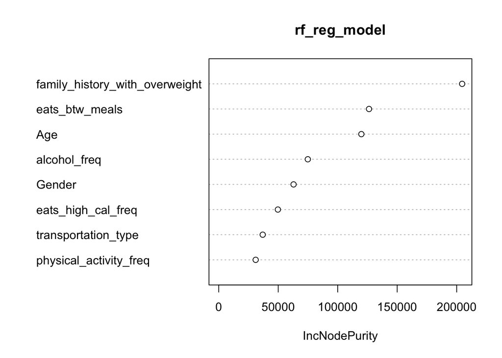

```r
varImpPlot(rf_reg_model)
```

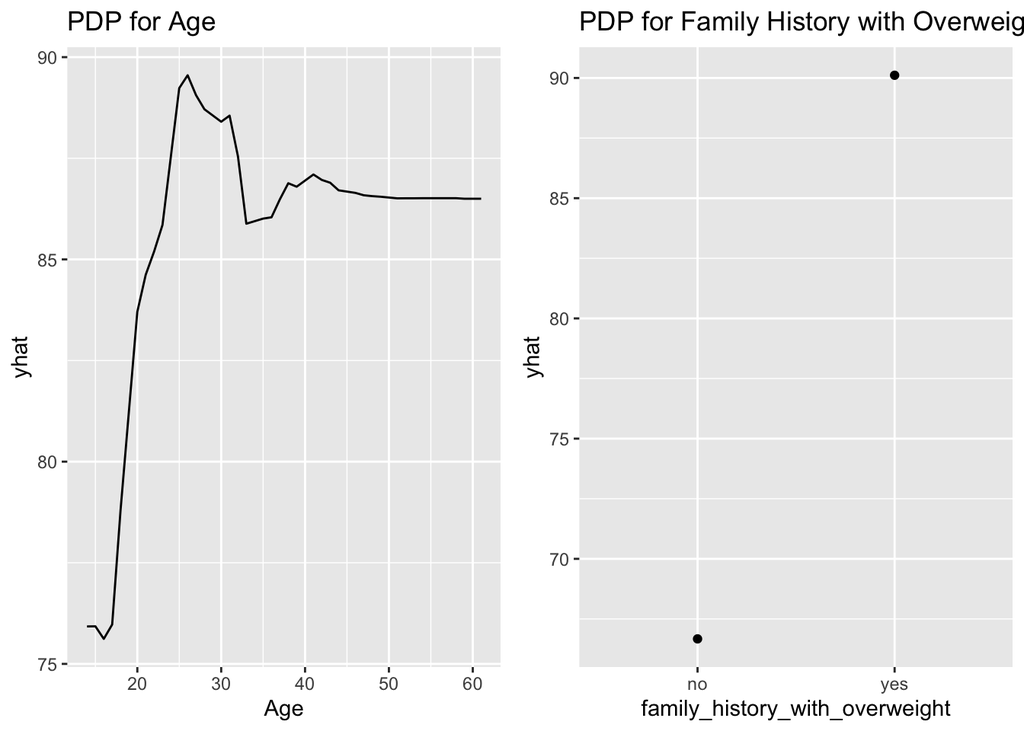

```r
# Create partial dependence plots (without plotting immediately)
pdp_age <- partial(rf_reg_model, pred.var = "Age", plot = FALSE, rug = TRUE)
pdp_family_history <- partial(rf_reg_model, pred.var = "family_history_with_overweight",
                              plot = FALSE, rug = TRUE)

# Plot both PDPs together
grid.arrange(
  autoplot(pdp_age) + ggtitle("PDP for Age"),
  autoplot(pdp_family_history) + ggtitle("PDP for Family History with Overweight"),
  ncol = 2
)
```

### 5.3 Gradient Boosting

Gradient Boosting is could be beneficial to use for my study because it excels at capturing complex, non-linear relationships and interactions among predictors like family_history_with_overweight and eats_high_cal_freq, which are critical for predicting Weight.

Its iterative boosting approach can improve predictive accuracy over Random Forest by focusing on correcting errors in previous iterations, making it a strong candidate for the predictive task of this study.

REsults:

Gradient Boosting achieved an RMSE of 16.88919, slightly higher than that of Random Forest’s with 16.81912 While both models perform well, **Random Forest** remains the **best** for predicting Weight due to its lower RMSE, indicating better predictive accuracy, though Gradient Boosting is a close competitor and could potentially improve with further tuning of hyperparameters

```r
set.seed(123)

ctrl <- trainControl(method = "cv", number = 5)
xgb_tune <- train(Weight ~ Age + family_history_with_overweight + eats_high_cal_freq +
                  physical_activity_freq + Gender + eats_btw_meals + alcohol_freq +
                  transportation_type,
                  data = training,
                  method = "xgbTree",
                  trControl = ctrl,
                  tuneGrid = expand.grid(nrounds = 100, max_depth = 3, eta = 0.1,
                                         gamma = 0, colsample_bytree = 0.8,
                                         min_child_weight = 1, subsample = 0.8))

# predicting on the test set
xgb_pred <- predict(xgb_tune, newdata = testing)

rmse_xgb <- sqrt(mean((xgb_pred - testing$Weight)^2))

cat("Gradient Boosting RMSE:", rmse_xgb, "\n")
```

```
Gradient Boosting RMSE: 16.88919
```

### 5.4 Ensemble

Ensemble methods are relevant to this study because they combine predictions from multiple models (such as Random Forest, Gradient Boosting, Ridge) to improve overall predictive accuracy for Weight, potentially reducing errors by leveraging the strengths of each model.

This approach can enhance my approach to the question at hand by balancing Random Forest’s ability to capture non-linear relationships with Ridge’s stability in handling linear effects, making it a practical way to achieve better performance in your obesity study.

Results:

The Ensemble method, although combining Random Forest, Gradient Boosting, and Ridge, returns an RMSE of 17.70022, which is higher than Random Forest’s and Gradient Boosting’s RMSEs.

Despite including Random Forest, the ensemble performs worse because averaging with higher values of RMSE of Ridge distorts the predictive power of the stronger models.

These results enable us to say that the **Random Forest remains the best model** so far with the lowest RMSE (16.81912), outperforming Gradient Boosting (16.88919) and the Ensemble (17.70022), making it the most accurate for predicting Weight due to its ability to handle non-linear relationships and interactions among predictors.

```r
# combining predictions from other methods
ensemble_pred <- (rf_reg_pred + xgb_pred + ridge_pred) / 3

rmse_ensemble <- sqrt(mean((ensemble_pred - testing$Weight)^2))

cat("Ensemble RMSE:", rmse_ensemble, "\n")
```

```
Ensemble RMSE: 17.70022
```

## 6 CONCLUSION

This study aimed to address two key questions: first, to classify individuals into obesity levels (Insufficient Weight, Normal Weight, Overweight, Obesity) based on demographic and lifestyle factors, and second, to predict individual weight as a numerical outcome to understand the impact of these factors. For the classification task, we employed QDA, Multinomial Logistic Regression, and Random Forest, using techniques like SMOTE for balancing the training data, cross-validation with caret, and threshold adjustments to improve minority class predictions. Random Forest emerged as the superior model with an accuracy of 0.9145 and Kappa of 0.8735, effectively handling class imbalance and providing robust predictions.

For the advanced regression task, we started with linear regression to interpret key predictors, identifying family_history_with_overweightyes as the most impactful, then explored Ridge, Lasso, Elastic Net, Random Forest, Gradient Boosting, and an ensemble method for prediction. Random Forest again outperformed others with the lowest RMSE of 16.81912, compared to Gradient Boosting (16.88919) and the ensemble (17.70022), due to its ability to capture non-linear relationships. We also used variable importance and partial dependence plots to enhance interpretability, confirming the significant influence of family history and eating habits on weight. These findings underscore the importance of non-linear models in obesity studies and suggest that family history and dietary behaviors are critical factors for both classification and prediction, offering valuable insights for health interventions and future research into obesity risk factors.